# Pemodelan_MPDW Praktikum

Muthi’ah Iffa Karimah

2025-10-02

```r
library(readxl)
library(tseries)
library(urca)
library(tseries)
library(tinytex)
library(TSA)
library(AICcmodavg)
library(lmtest)
library(forecast)
```

# Import Data

```r
data.sales = read_excel("C:\\Users\\MUTHI'AH IFFA\\Downloads\\Semester 5\\MPDW\\Praktikum\\Tugas Mandiri Iffa_MPDW_(store sales) 301_400.xlsx")
data.sales = data.sales[1:100,]
data.sales.ts = ts(data.sales)
```

# Cek Struktur Data

```r
data.sales
```

```
## # A tibble: 100 × 2
##    Date                Total_Sales
##    <dttm>                    <dbl>
##  1 2022-10-28 00:00:00        238.
##  2 2022-10-29 00:00:00        204.
##  3 2022-10-30 00:00:00        207.
##  4 2022-10-31 00:00:00        250.
##  5 2022-11-01 00:00:00        236.
##  6 2022-11-02 00:00:00        286.
##  7 2022-11-03 00:00:00        226.
##  8 2022-11-04 00:00:00        214.
##  9 2022-11-05 00:00:00        230.
## 10 2022-11-06 00:00:00        204.
## # ℹ 90 more rows
```

```r
str(data.sales)
```

```
## tibble [100 × 2] (S3: tbl_df/tbl/data.frame)
##  $ Date       : POSIXct[1:100], format: "2022-10-28" "2022-10-29" ...
##  $ Total_Sales: num [1:100] 238 204 207 250 236 ...
```

```r
head(data.sales)
```

```
## # A tibble: 6 × 2
##   Date                Total_Sales
##   <dttm>                    <dbl>
## 1 2022-10-28 00:00:00        238.
## 2 2022-10-29 00:00:00        204.
## 3 2022-10-30 00:00:00        207.
## 4 2022-10-31 00:00:00        250.
## 5 2022-11-01 00:00:00        236.
## 6 2022-11-02 00:00:00        286.
```

# Buat Data Time Series & Cek Stationeritas

```r
# Ambil kolom nilai penjualan
y = data.sales$Total_Sales
head(y)
```

```
## [1] 238.49 204.26 207.48 250.01 236.39 286.10
```

```r
# Buat Objek Time series
ts.data = ts(y, frequency = 1, start = 1) # frequency 1 karena data berjumlah 100
head(ts.data)
```

```
## Time Series:
## Start = 1
## End = 6
## Frequency = 1
## [1] 238.49 204.26 207.48 250.01 236.39 286.10
```

data bulanan –> frquency = 12 (karena 12 bulan/tahun)

data kuartal –> frequency = 4

data harian satu tahun penuh –> frequency = 365

tidak tahu ada musiman/data pendek –> frequency = 1

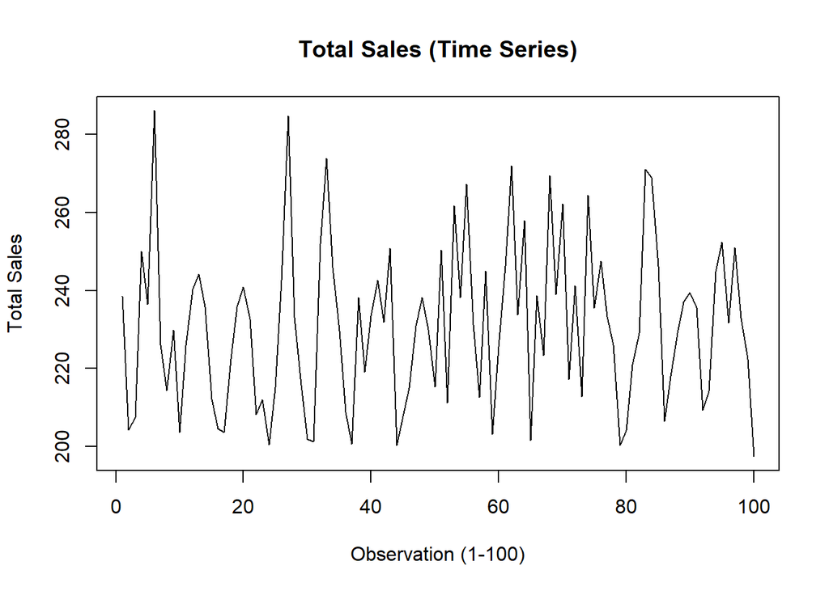

```r
# Plot deret waktu
plot(ts.data,
     main = "Total Sales (Time Series)",
     ylab = "Total Sales",
     xlab = "Observation (1-100)")
```

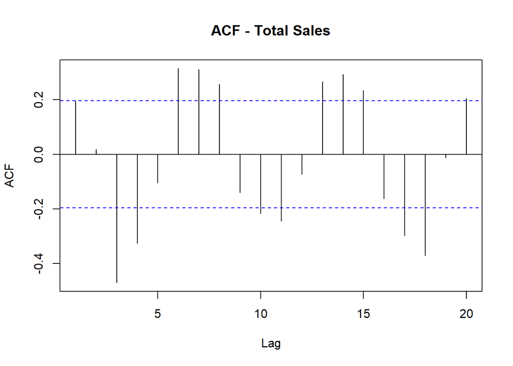

```r
# Plot ACF dan PACF
acf(ts.data, main = "ACF - Total Sales") # plot ACF
```

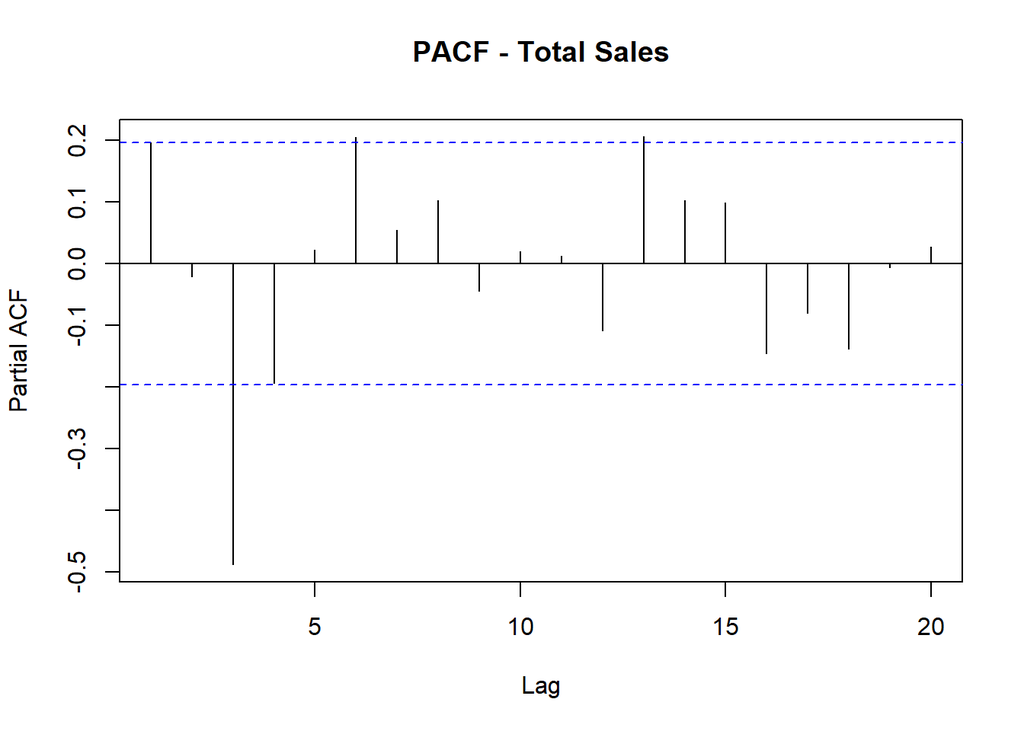

```r
pacf(ts.data, main = "PACF - Total Sales") # plot PACF
```

# Uji stationeritas

## ADF Test

ADF test mendeteksi unit root

$H_0$ = data tidak stationer

$H_1$ = data stationer

tolak $H_0$ ketika < 0.05

```r
# Uji ADF
adf.test(ts.data)
```

```
##
##  Augmented Dickey-Fuller Test
##
## data:  ts.data
## Dickey-Fuller = -6.0915, Lag order = 4, p-value = 0.01
## alternative hypothesis: stationary
```

## KPSS (Kwiatkowski-Phillips-Schmidt-Shin) Test

KPSS test mendeteksi kestationeran di sekitar mean atau tren

$H_0$ = data stationer

$H_1$ = data tidak stationer

tolak $H_0$ ketika p-value < 0.05

```r
# Uji KPSS
kpss.test(ts.data)
```

```
##
##  KPSS Test for Level Stationarity
##
## data:  ts.data
## KPSS Level = 0.21043, Truncation lag parameter = 4, p-value = 0.1
```

# Pemodelan

Menggunakan data.sales dengan 100 amatan yang sudah dicek stationeritasnya.

## Eksplorasi Data

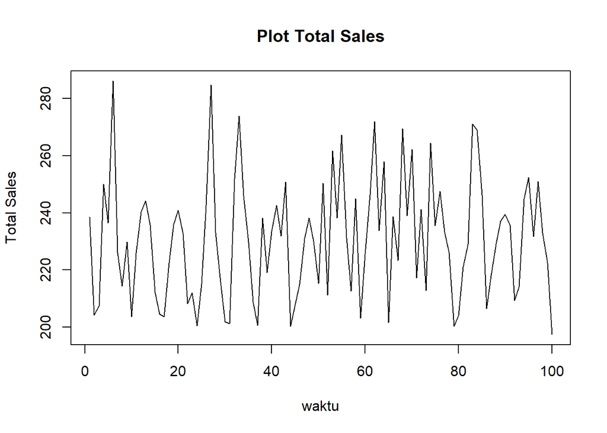

```r
plot.ts(ts.data, lty = 1, xlab = "waktu", ylab = "Total Sales", main = "Plot Total Sales")
```

berdasarkan plot deret waktu dari data.sales terlihat bahwa data amatan cenderung sudah staitioner.

pembagian data akan dilakukan dengan proporsi 80:20

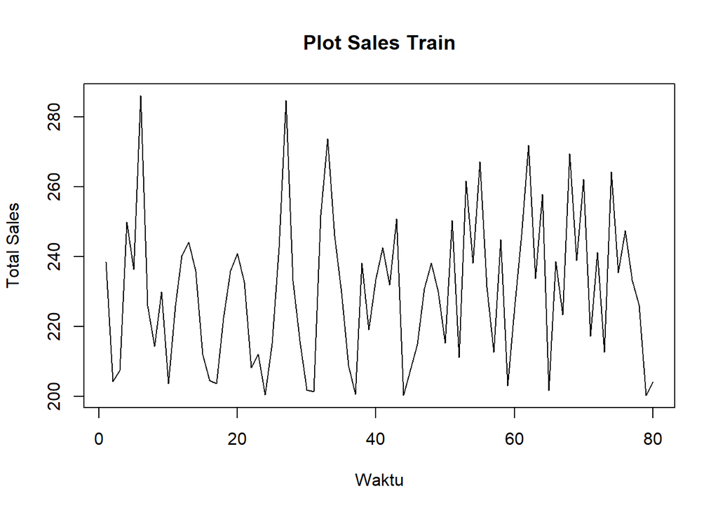

```r
# Data latih
sales.train = data.sales$Total_Sales[1:80]
train.ts = ts(sales.train)
plot.ts(sales.train,
        lty = 1,
        xlab = "Waktu",
        ylab = "Total Sales",
        main = "Plot Sales Train")
```

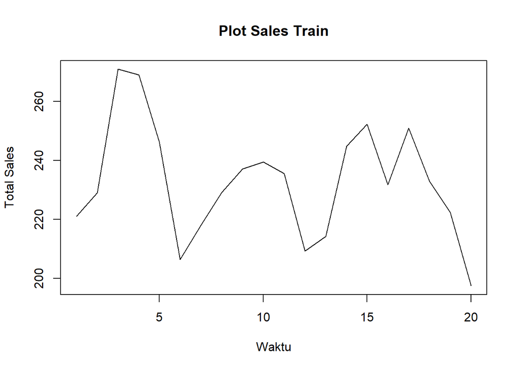

```r
# Data test
sales.test = data.sales$Total_Sales[81:100]
test.ts = ts(sales.test)
plot.ts(sales.test,
        lty = 1,
        xlab = "Waktu",
        ylab = "Total Sales",
        main = "Plot Sales Train")
```

## Plot Data Uji

### Uji Stationeritas data

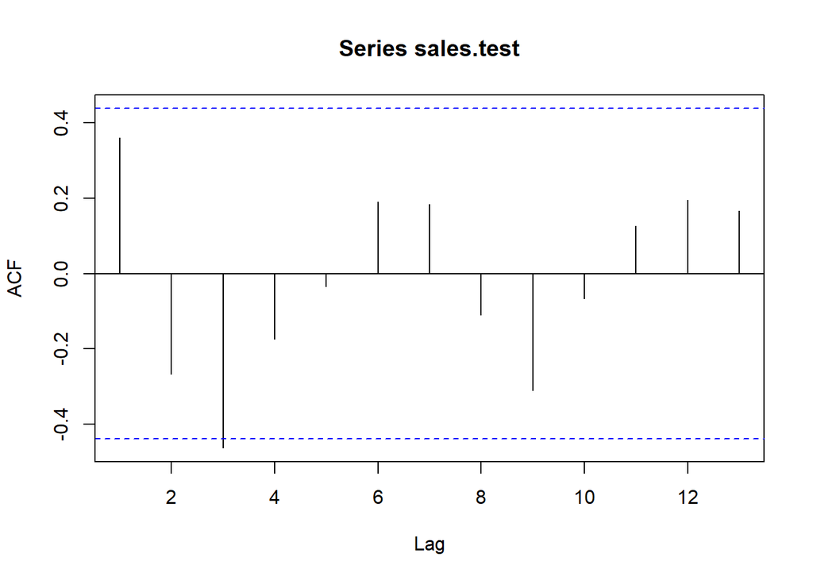

```r
# Data latih
acf(sales.test)
```

### Uji ADF

$H_0$ = Data tidak stationer dalam rataan

$H_1$ = Data stationer dalam rataan

Tolak $H_0$ ketika $p-value$ < 0.05

```r
tseries::adf.test(sales.train)
```

```
##
##  Augmented Dickey-Fuller Test
##
## data:  sales.train
## Dickey-Fuller = -5.2203, Lag order = 4, p-value = 0.01
## alternative hypothesis: stationary
```

Hasil ADF menunjukkan bahwa didapat $p-value$ = 0.01 yang lebih kecil dari taraf nyata 5% ($p-value$ < 0.05). Artinya tolak $H_0$ dapat disimpulkan bahwa **data stationer dalam rataan.**

Maka tidak diperlukan transformasi box-cox

### Plot ACF

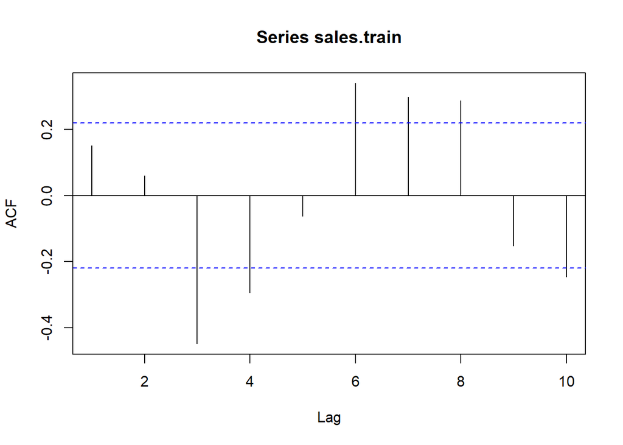

```r
# Plot ACF
acf(sales.train, lag.max = 10)
```

### Plot PACF

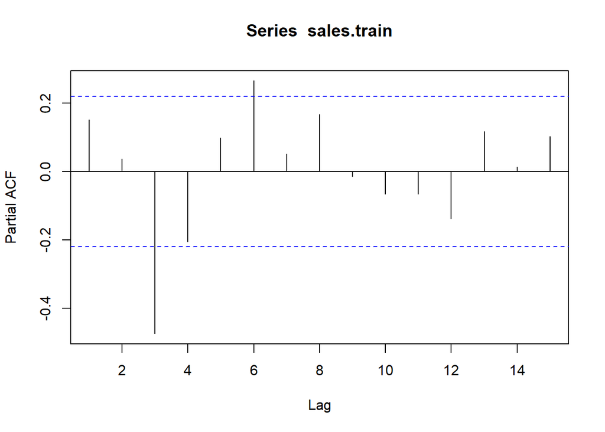

```r
pacf(sales.train, lag.max = 15)
```

Jika plot ACF dan PACF dianggap tails off, maka model yang terbentuk adalah ARIMA (2, 0, 2)

### Plot EACF

```r
eacf(sales.train)
```

```
## AR/MA
##   0 1 2 3 4 5 6 7 8 9 10 11 12 13
## 0 o o x x o x x x o x x  o  o  x
## 1 x o x o o x o x o o o  o  o  o
## 2 o x x o o x o x o o o  o  o  o
## 3 x x x o o o o o o o o  o  o  o
## 4 x x x o o o o o o o o  o  o  o
## 5 x x o o x o o o o o o  o  o  o
## 6 x x o x o o o o o o o  o  o  o
## 7 x x o o o o o o o o o  o  o  o
```

Identifikasi model dengan plot EACF, terbentuk pola ujung segitiga nol. Model tentatif yang terbentuk adalah ARIMA (3, 0, 3)

(kak ini kyk gimana yah aku bingung di plot ACF, PACF, sama EACF kok modelnya beda beda yah… minta feedbacknya kak boleh tak:)?)

# Pendugaan Parameter Model Tentatif

```r
# ARIMA (0,0,2)
model1.da = Arima(sales.train, order = c(0,0,2), method = "ML")
summary(model1.da)
```

```
## Series: sales.train
## ARIMA(0,0,2) with non-zero mean
##
## Coefficients:
##         ma1     ma2      mean
##       0.298  0.4893  230.3692
## s.e.  0.093  0.1109    3.9161
##
## sigma^2 = 406.1:  log likelihood = -352.54
## AIC=713.09   AICc=713.62   BIC=722.61
##
## Training set error measures:
##                       ME     RMSE      MAE        MPE     MAPE      MASE
## Training set -0.06034901 19.77007 16.52346 -0.6855156 7.121838 0.7076046
##                     ACF1
## Training set -0.04155337
```

```r
lmtest::coeftest(model1.da)
```

```
##
## z test of coefficients:
##
##             Estimate Std. Error z value  Pr(>|z|)
## ma1         0.298030   0.093049  3.2029   0.00136 **
## ma2         0.489251   0.110856  4.4134 1.018e-05 ***
## intercept 230.369166   3.916060 58.8268 < 2.2e-16 ***
## ---
## Signif. codes:  0 '***' 0.001 '**' 0.01 '*' 0.05 '.' 0.1 ' ' 1
```

```r
# ARIMA (2,0,0)
model2.da = Arima(sales.train, order = c(2,0,0), method = "ML")
summary(model2.da)
```

```
## Series: sales.train
## ARIMA(2,0,0) with non-zero mean
##
## Coefficients:
##          ar1     ar2      mean
##       0.1470  0.0411  230.5048
## s.e.  0.1119  0.1140    2.8822
##
## sigma^2 = 457.2:  log likelihood = -357.01
## AIC=722.01   AICc=722.54   BIC=731.54
##
## Training set error measures:
##                       ME     RMSE      MAE        MPE     MAPE      MASE
## Training set -0.00670896 20.97758 17.04422 -0.8094011 7.387632 0.7299056
##                   ACF1
## Training set 0.0213556
```

```r
lmtest::coeftest(model2.da)
```

```
##
## z test of coefficients:
##
##             Estimate Std. Error z value Pr(>|z|)
## ar1         0.146983   0.111909  1.3134   0.1890
## ar2         0.041114   0.113956  0.3608   0.7183
## intercept 230.504791   2.882153 79.9766   <2e-16 ***
## ---
## Signif. codes:  0 '***' 0.001 '**' 0.01 '*' 0.05 '.' 0.1 ' ' 1
```

```r
# ARIMA (3,0,3)
model3.da = Arima(sales.train, order = c(3,0,3), method = "ML")
summary(model3.da)
```

```
## Series: sales.train
## ARIMA(3,0,3) with non-zero mean
##
## Coefficients:
##          ar1     ar2      ar3      ma1     ma2     ma3      mean
##       0.4000  0.0549  -0.8459  -0.5712  0.1190  0.6930  231.1197
## s.e.  0.1488  0.1853   0.1483   0.2618  0.3062  0.1917    1.5470
##
## sigma^2 = 262.7:  log likelihood = -336.33
## AIC=688.67   AICc=690.69   BIC=707.72
##
## Training set error measures:
##                      ME     RMSE      MAE        MPE     MAPE     MASE
## Training set -0.2880938 15.48224 12.62435 -0.5462405 5.376372 0.540628
##                    ACF1
## Training set 0.04875799
```

```r
lmtest::coeftest(model3.da)
```

```
##
## z test of coefficients:
##
##             Estimate Std. Error  z value  Pr(>|z|)
## ar1         0.400004   0.148793   2.6883 0.0071812 **
## ar2         0.054914   0.185337   0.2963 0.7670074
## ar3        -0.845888   0.148286  -5.7045 1.167e-08 ***
## ma1        -0.571155   0.261801  -2.1816 0.0291363 *
## ma2         0.119048   0.306208   0.3888 0.6974369
## ma3         0.693047   0.191707   3.6151 0.0003002 ***
## intercept 231.119720   1.547021 149.3966 < 2.2e-16 ***
## ---
## Signif. codes:  0 '***' 0.001 '**' 0.01 '*' 0.05 '.' 0.1 ' ' 1
```

```r
# Cek signifikansi parameter tiap model
models <- list(
  "ARIMA(0,0,2)" = model1.da,
  "ARIMA(2,0,0)" = model2.da,
  "ARIMA(3,0,3)" = model3.da
)

lapply(models, coeftest)
```

```
## $`ARIMA(0,0,2)`
##
## z test of coefficients:
##
##             Estimate Std. Error z value  Pr(>|z|)
## ma1         0.298030   0.093049  3.2029   0.00136 **
## ma2         0.489251   0.110856  4.4134 1.018e-05 ***
## intercept 230.369166   3.916060 58.8268 < 2.2e-16 ***
## ---
## Signif. codes:  0 '***' 0.001 '**' 0.01 '*' 0.05 '.' 0.1 ' ' 1
##
##
## $`ARIMA(2,0,0)`
##
## z test of coefficients:
##
##             Estimate Std. Error z value Pr(>|z|)
## ar1         0.146983   0.111909  1.3134   0.1890
## ar2         0.041114   0.113956  0.3608   0.7183
## intercept 230.504791   2.882153 79.9766   <2e-16 ***
## ---
## Signif. codes:  0 '***' 0.001 '**' 0.01 '*' 0.05 '.' 0.1 ' ' 1
##
##
## $`ARIMA(3,0,3)`
##
## z test of coefficients:
##
##             Estimate Std. Error  z value  Pr(>|z|)
## ar1         0.400004   0.148793   2.6883 0.0071812 **
## ar2         0.054914   0.185337   0.2963 0.7670074
## ar3        -0.845888   0.148286  -5.7045 1.167e-08 ***
## ma1        -0.571155   0.261801  -2.1816 0.0291363 *
## ma2         0.119048   0.306208   0.3888 0.6974369
## ma3         0.693047   0.191707   3.6151 0.0003002 ***
## intercept 231.119720   1.547021 149.3966 < 2.2e-16 ***
## ---
## Signif. codes:  0 '***' 0.001 '**' 0.01 '*' 0.05 '.' 0.1 ' ' 1
```

Untuk cari model overfitting, identifikasi AIC terkecil dan seluruh parameternya signifikan.

# Analisis Sisaan

### Eksplorasi

```r
# Eksplorasi
sisaan.da = model2.da$residuals
par(mforw = c(2,2))
```

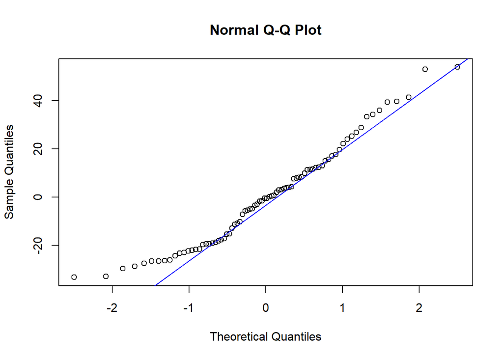

```r
qqnorm(sisaan.da)
qqline(sisaan.da,
       col = "blue",
       lwd = 1)
```

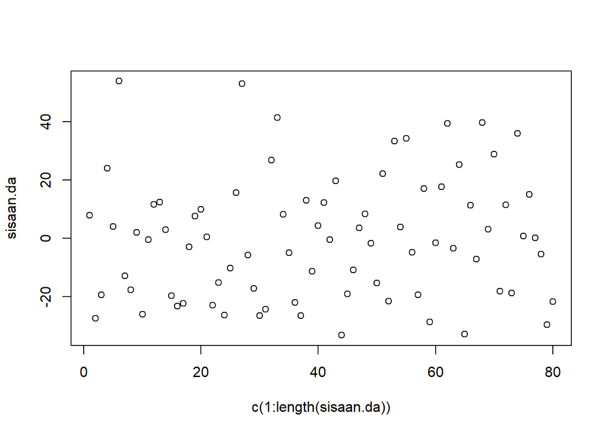

```r
plot(c(1:length(sisaan.da)),
     sisaan.da)
```

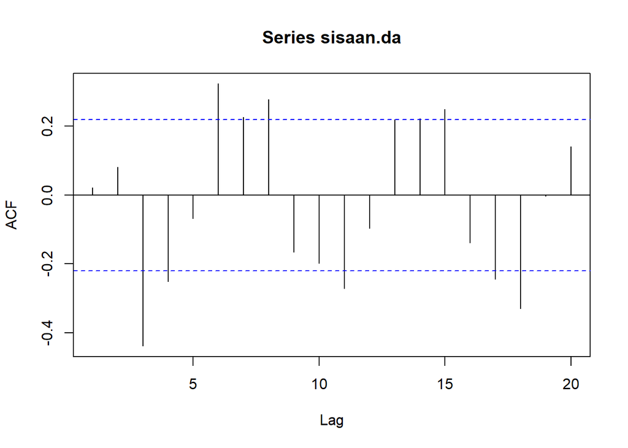

```r
acf(sisaan.da, lag.max = 20)
```

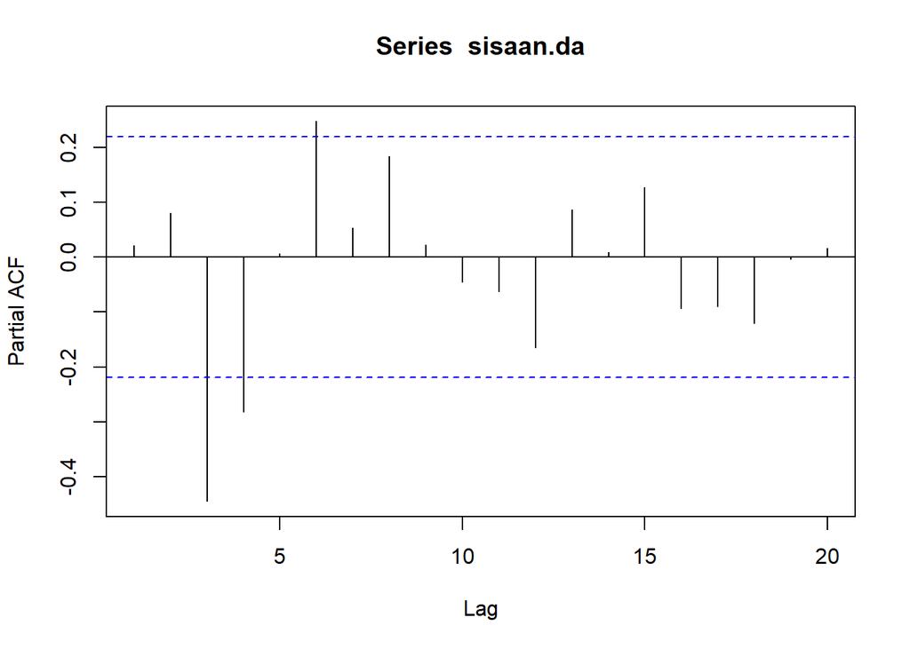

```r
pacf(sisaan.da, lag.max = 20)
```